# Home Price Prediction

Ian Donovan

6/19/2020

# Introduction

In this project I am going to be examining a dataset of home characteristics in King County, WA. I will use the variables in the dataset to attempt to predict home prices.

```r
library(dplyr)
library(ggplot2)
library(tree)
library(randomForest)
library(xgboost)
library(caret)
library(nnet)
```

## Reading in The Data

Here we will remove zip code, sqft of the basement (collinear with sqft_living), and year renovated (collinear with year built)

```r
homes = read.csv('kc_house_data.csv')

homes_feat = select(homes, -1:-2)

homes_feat$renovated = ifelse(homes_feat$yr_renovated>0,1,0) # Indicates if a house has been remodeled
homes_feat$basement = ifelse(homes_feat$sqft_basement>0,1,0) # Indicated if a house has a basement


homes_feat = select(homes_feat, -12, -14, -15) # remove zipcode, sqft basement, and year renovated
head(homes_feat)
```

```
##     price bedrooms bathrooms sqft_living sqft_lot floors waterfront view
## 1  221900        3      1.00        1180     5650      1          0    0
## 2  538000        3      2.25        2570     7242      2          0    0
## 3  180000        2      1.00         770    10000      1          0    0
## 4  604000        4      3.00        1960     5000      1          0    0
## 5  510000        3      2.00        1680     8080      1          0    0
## 6 1225000        4      4.50        5420   101930      1          0    0
##   condition grade sqft_above yr_built     lat     long sqft_living15 sqft_lot15
## 1         3     7       1180     1955 47.5112 -122.257          1340       5650
## 2         3     7       2170     1951 47.7210 -122.319          1690       7639
## 3         3     6        770     1933 47.7379 -122.233          2720       8062
## 4         5     7       1050     1965 47.5208 -122.393          1360       5000
## 5         3     8       1680     1987 47.6168 -122.045          1800       7503
## 6         3    11       3890     2001 47.6561 -122.005          4760     101930
##   renovated basement
## 1         0        0
## 2         1        1
## 3         0        0
## 4         0        1
## 5         0        0
## 6         0        1
```

## Exploratory Data Analysis

```r
mean(homes_feat$price)
```

```
## [1] 540088.1
```

```r
median(homes_feat$price)
```

```
## [1] 450000
```

```r
sd(homes_feat$price)
```

```
## [1] 367127.2
```

```r
sum(is.na(homes_feat))
```

```
## [1] 0
```

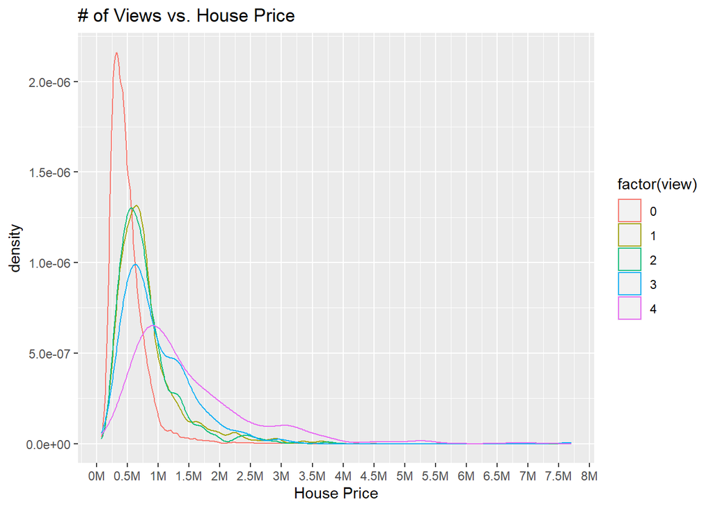

```r
#Lets check out what the price distribution looks like in regard to the number of views
ggplot(homes_feat)+
  geom_density(aes(price, color=factor(view))) +
  labs(title='# of Views vs. House Price', x='House Price') +
  scale_x_continuous(breaks=seq(0,8000000, by=500000), labels= paste(seq(0,8,.5), "M", sep=""))
```

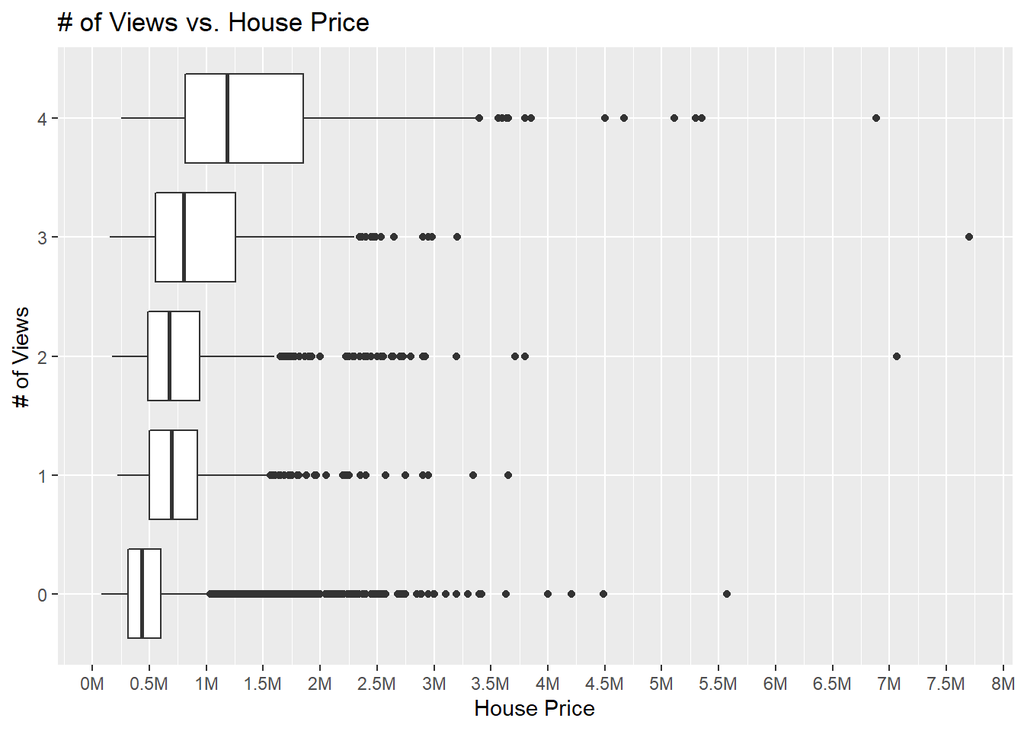

```r
#Boxplot to examine outliers
ggplot(homes_feat, aes(x=factor(view), y=price)) +
  geom_boxplot() +
  coord_flip() +
  labs(title='# of Views vs. House Price', x='# of Views', y='House Price') +
  scale_y_continuous(breaks=seq(0,8000000, by=500000), labels= paste(seq(0,8,.5), "M", sep=""))
```

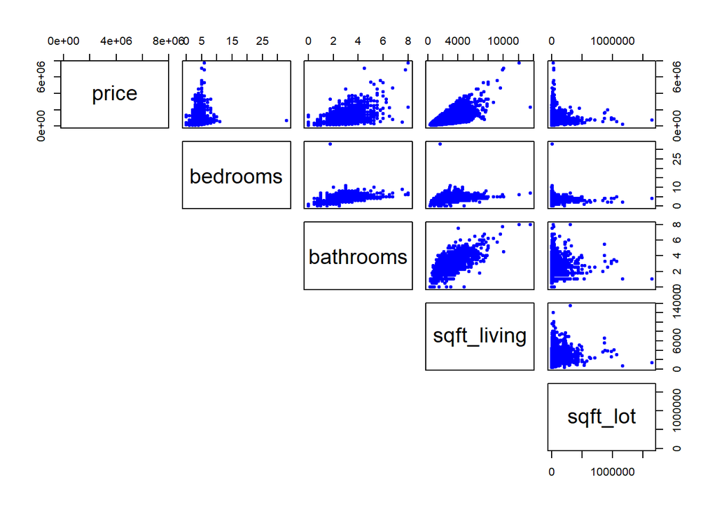

```r
#Scatterplot matrix of a selection of the response and a selection of features
pairs(select(homes_feat, 1:5),
      lower.panel = NULL,
      col='blue',
      pch = 20)
```

## Creating the Training and Test Set

In this example we will work with a 65% train test split, from past work with this dataset the 65% split appears to produce better results than an 80% or 50% split.

```r
set.seed(1)
train = sample(1:nrow(homes_feat), .65*nrow(homes_feat))
test = -train
```

# Formal Analysis

## Linear Regression

To begin, we fit a multiple linear regression to the training set before making predictions on the test set. We will use the RMSE from this model as a baseline when comparing model perfomance later.

```r
lmod = lm(price~., data=homes_feat[train,])
  summary(lmod)
```

```
##
## Call:
## lm(formula = price ~ ., data = homes_feat[train, ])
##
## Residuals:
##      Min       1Q   Median       3Q      Max
## -1142881   -97828    -9191    77120  4326381
##
## Coefficients:
##                 Estimate Std. Error t value Pr(>|t|)
## (Intercept)   -3.603e+07  1.959e+06 -18.390  < 2e-16 ***
## bedrooms      -3.416e+04  2.271e+03 -15.043  < 2e-16 ***
## bathrooms      3.798e+04  4.009e+03   9.473  < 2e-16 ***
## sqft_living    1.711e+02  7.611e+00  22.485  < 2e-16 ***
## sqft_lot       1.986e-01  6.444e-02   3.082  0.00206 **
## floors         6.765e+03  4.390e+03   1.541  0.12331
## waterfront     6.435e+05  2.138e+04  30.092  < 2e-16 ***
## view           4.670e+04  2.619e+03  17.829  < 2e-16 ***
## condition      3.006e+04  2.842e+03  10.575  < 2e-16 ***
## grade          9.503e+04  2.666e+03  35.641  < 2e-16 ***
## sqft_above     8.755e+00  8.435e+00   1.038  0.29932
## yr_built      -2.421e+03  8.790e+01 -27.539  < 2e-16 ***
## lat            5.594e+05  1.288e+04  43.420  < 2e-16 ***
## long          -1.105e+05  1.473e+04  -7.503 6.61e-14 ***
## sqft_living15  2.449e+01  4.218e+00   5.807 6.49e-09 ***
## sqft_lot15    -4.529e-01  9.228e-02  -4.908 9.30e-07 ***
## renovated      3.865e+04  9.019e+03   4.285 1.84e-05 ***
## basement      -1.478e+04  6.463e+03  -2.287  0.02222 *
## ---
## Signif. codes:  0 '***' 0.001 '**' 0.01 '*' 0.05 '.' 0.1 ' ' 1
##
## Residual standard error: 199000 on 14030 degrees of freedom
## Multiple R-squared:  0.7033, Adjusted R-squared:  0.703
## F-statistic:  1957 on 17 and 14030 DF,  p-value: < 2.2e-16
```

```r
  preds = predict(lmod, homes_feat[test,])

  mse = mean((preds-homes_feat[test,1])^2);
  rmse = sqrt(mean((preds-homes_feat[test,1])^2));

mse
```

```
## [1] 43976059369
```

```r
rmse; #In this case we were able to obtain an RMSE of $209,704.7
```

```
## [1] 209704.7
```

## Decision Trees - General

Using decision trees alone doesn’t appear to be improving our results very much. Best RMSE = $212,242.50 (65% training set)

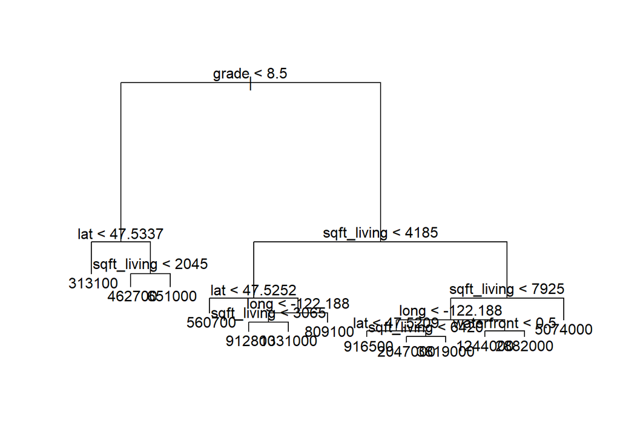

```r
#Decision Tree
set.seed(1)
tree.homes = tree(price~.,data=homes_feat, subset=train)
  {plot(tree.homes)
  text(tree.homes,pretty=0)};
```

```r
  summary(tree.homes)
```

```
##
## Regression tree:
## tree(formula = price ~ ., data = homes_feat, subset = train)
## Variables actually used in tree construction:
## [1] "grade"       "lat"         "sqft_living" "long"        "waterfront"
## Number of terminal nodes:  13
## Residual mean deviance:  3.939e+10 = 5.528e+14 / 14040
## Distribution of residuals:
##     Min.  1st Qu.   Median     Mean  3rd Qu.     Max.
## -2794000   -97690   -24700        0    69960  2626000
```

```r
  tree.homes;
```

```
## node), split, n, deviance, yval
##       * denotes terminal node
##
##   1) root 14048 1.873e+15  538300
##     2) grade < 8.5 11294 4.187e+14  435100
##       4) lat < 47.5337 4740 6.105e+13  313100 *
##       5) lat > 47.5337 6554 2.361e+14  523300
##        10) sqft_living < 2045 4445 8.808e+13  462700 *
##        11) sqft_living > 2045 2109 9.735e+13  651000 *
##     3) grade > 8.5 2754 8.398e+14  961700
##       6) sqft_living < 4185 2384 3.082e+14  851000
##        12) lat < 47.5252 519 2.291e+13  560700 *
##        13) lat > 47.5252 1865 2.294e+14  931800
##          26) long < -122.188 820 1.509e+14 1088000
##            52) sqft_living < 3065 476 4.870e+13  912800 *
##            53) sqft_living > 3065 344 6.731e+13 1331000 *
##          27) long > -122.188 1045 4.267e+13  809100 *
##       7) sqft_living > 4185 370 3.141e+14 1675000
##        14) sqft_living < 7925 363 2.077e+14 1610000
##          28) long < -122.188 156 1.142e+14 2011000
##            56) lat < 47.5209 16 5.312e+12  916500 *
##            57) lat > 47.5209 140 8.759e+13 2136000
##             114) sqft_living < 6420 133 6.023e+13 2047000 *
##             115) sqft_living > 6420 7 6.475e+12 3819000 *
##          29) long > -122.188 207 4.942e+13 1307000
##            58) waterfront < 0.5 199 2.688e+13 1244000 *
##            59) waterfront > 0.5 8 1.921e+12 2882000 *
##        15) sqft_living > 7925 7 2.392e+13 5074000 *
```

```r
  preds = predict(tree.homes, homes_feat[test,])
  mse = mean((preds-homes_feat[test,1])^2)
  rmse = sqrt(mean((preds-homes_feat[test,1])^2));

  mse
```

```
## [1] 45046882235
```

```r
  rmse;
```

```
## [1] 212242.5
```

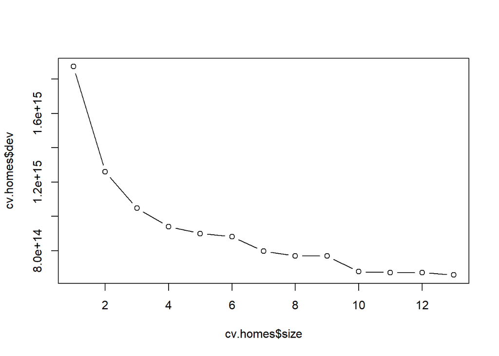

```r
#Cross validating the number of splits
set.seed(1)
cv.homes=cv.tree(tree.homes)
  plot(cv.homes$size ,cv.homes$dev ,type='b');
```

```r
  prune.homes = prune.tree(tree.homes, best=10);

  preds = predict(prune.homes, homes_feat[test,])
  mse = mean((preds-homes_feat[test,1])^2)
  rmse = sqrt(mean((preds-homes_feat[test,1])^2));

  mse
```

```
## [1] 48155502190
```

```r
  rmse;
```

```
## [1] 219443.6
```

## Bagging - General

Model Performance improves dramatically with the use of bagged decision trees. We use ntree = 35 as this has given good results with this dataset in the past. Best RMSE = $129,413.10 (65% training set).

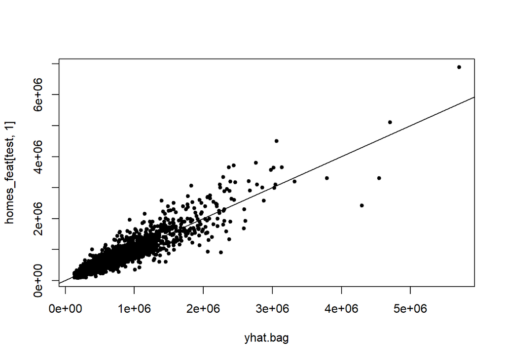

```r
set.seed(1)
bag.homes = randomForest(price~., data=homes_feat, subset=train, mtry=17, ntree=35, importance=T)
  yhat.bag = predict(bag.homes, homes_feat[test,])
  {plot(yhat.bag, homes_feat[test,1], pch = 20)
  abline(0,1)};
```

```r
  mse = mean((yhat.bag-homes_feat[test,1])^2)
  rmse = sqrt(mean((yhat.bag-homes_feat[test,1])^2));

  mse
```

```
## [1] 16747746414
```

```r
  rmse;
```

```
## [1] 129413.1
```

## Random Forest - General

```r
#mtry= 6
set.seed(1)
rf.homes = randomForest(price~., data=homes_feat, subset=train, mtry=6, ntree=35, importance=T)
  yhat.rf = predict(rf.homes, homes_feat[test,])
  mse = mean((yhat.rf-homes_feat[test,1])^2)
  rmse = sqrt(mean((yhat.rf-homes_feat[test,1])^2));

  mse
```

```
## [1] 18698408300
```

```r
  rmse;
```

```
## [1] 136742.1
```

```r
  importance(rf.homes)
```

```
##                 %IncMSE IncNodePurity
## bedrooms       4.622199  1.296743e+13
## bathrooms      1.722206  8.769549e+13
## sqft_living    9.534837  4.193323e+14
## sqft_lot       7.797101  3.729933e+13
## floors         2.588274  6.568588e+12
## waterfront     9.852545  4.860650e+13
## view           5.218281  4.761517e+13
## condition      3.687775  9.103689e+12
## grade         10.937230  4.054903e+14
## sqft_above     5.785095  1.292312e+14
## yr_built      11.591259  6.948985e+13
## lat           42.876954  2.510880e+14
## long          17.195531  1.073945e+14
## sqft_living15  7.622941  1.403440e+14
## sqft_lot15     7.056610  3.581855e+13
## renovated      2.180606  4.883198e+12
## basement       3.600945  1.097279e+13
```

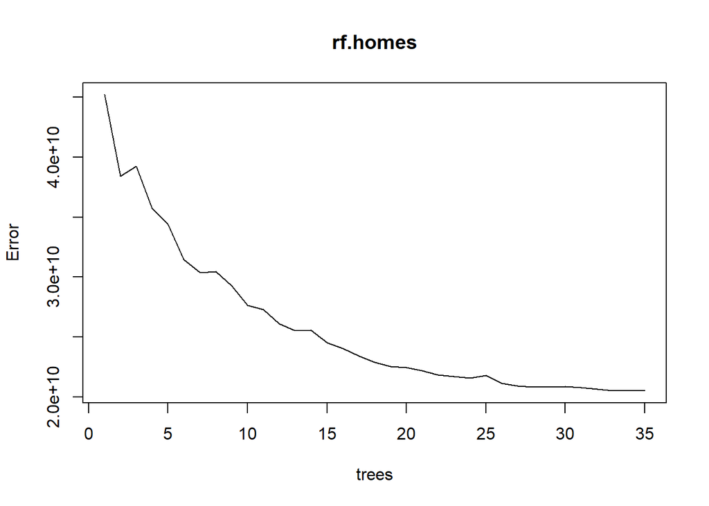

```r
  plot(rf.homes);
```

```r
#mtry= 4
set.seed(1)
rf.homes = randomForest(price~., data=homes_feat, subset=train, mtry=4, ntree=35, importance=T)
  yhat.rf = predict(rf.homes, homes_feat[test,])
  mse = mean((yhat.rf-homes_feat[test,1])^2)
  rmse = sqrt(mean((yhat.rf-homes_feat[test,1])^2));

  mse
```

```
## [1] 19177983866
```

```r
  rmse;
```

```
## [1] 138484.6
```

## Boosting

Here we will use the xgboost package for faster runtime. We will need a model matrix.

```r
#Create Model Matrix
x=model.matrix(price~.,homes_feat)[,-1]
y=homes_feat$price

features_train = x[train,]
response_train = y[train]

features_test = x[test,]
response_test = y[test]
```

### Creating a boosted model.

We start by trying some numbers and seeing what works decent for the parameter values, later we will use a grid search to find the best values.

- Eta: (learning rate)
- max_depth: (interaction depth)
- min_child_weight: (min observations in a terminal node)
- subsample: allows for stochastic gradient descent (this allows xgboost to randomly sample training data before growing trees)

The RMSE from this first attempt was $128,942.40.

```r
set.seed(1)
params <- list(
  eta = .3,
  max_depth = 5,
  min_child_weight = 5,
  subsample = .8,
  colsample_bytree = 1
)

xgb.fit1 <- xgboost(
  data = features_train,
  label = response_train,
  params = params,
  nrounds = 964,
  objective = "reg:linear",  # for regression models
  verbose = 0,               # silent,
)

  preds = predict(xgb.fit1,features_test)
  mse = mean((preds-response_test)^2)
  rmse = sqrt(mean((preds-response_test)^2));

  mse
```

```
## [1] 16626143301
```

```r
  rmse;
```

```
## [1] 128942.4
```

```r
  # create importance matrix
  importance_matrix <- xgb.importance(model = xgb.fit1)
  importance_matrix
```

```
##           Feature         Gain       Cover   Frequency
##  1:         grade 0.3000050404 0.020670743 0.022876413
##  2:   sqft_living 0.2736642740 0.101178629 0.101029894
##  3:           lat 0.1577224785 0.146486347 0.149790376
##  4:          long 0.0686280932 0.101252162 0.114427634
##  5: sqft_living15 0.0389247262 0.118105345 0.106133795
##  6:    waterfront 0.0364455020 0.002700511 0.001458257
##  7:      yr_built 0.0285584959 0.074905351 0.085627051
##  8:    sqft_above 0.0242290796 0.089313559 0.087130879
##  9:          view 0.0205847455 0.011556696 0.012030623
## 10:    sqft_lot15 0.0149174344 0.117084351 0.112149107
## 11:      sqft_lot 0.0143014168 0.115241049 0.113014947
## 12:     bathrooms 0.0096531607 0.030495377 0.034633613
## 13:     condition 0.0056453428 0.039749469 0.021782720
## 14:      bedrooms 0.0025480998 0.018766453 0.018957346
## 15:     renovated 0.0022031496 0.004090295 0.003281079
## 16:        floors 0.0016159830 0.005391027 0.009888808
## 17:      basement 0.0003529775 0.003012637 0.005787459
```

### Grid Search.

We can use a grid search to help find the optimal tuning parameters, we only try a few here since this can take a long time to finish compiling. Setting subsample to .8 allows for stochastic gradient descent.

```r
hyper_grid <- expand.grid(
  eta = c(.05, .1, .15),
  max_depth = c(1, 3, 5),
  min_child_weight = c(2, 3, 5),
  subsample = .8,
  colsample_bytree = 1,
  optimal_trees = 0,               # a place to dump results
  min_RMSE = 0                     # a place to dump results
)

for(i in 1:nrow(hyper_grid)) {

  # create parameter list
  params <- list(
    eta = hyper_grid$eta[i],
    max_depth = hyper_grid$max_depth[i],
    min_child_weight = hyper_grid$min_child_weight[i],
    subsample = hyper_grid$subsample[i],
    colsample_bytree = hyper_grid$colsample_bytree[i]
  )

  # reproducibility
  set.seed(1)

  # train model
  xgb.tune <- xgb.cv(
    params = params,
    data = features_train,
    label = response_train,
    nrounds = 5000,
    nfold = 5,
    objective = "reg:linear",  # for regression models
    verbose = 0,               # silent,
    early_stopping_rounds = 10 # stop if no improvement for 10 consecutive trees
  )

  # add min training error and trees to grid
  hyper_grid$optimal_trees[i] <- which.min(xgb.tune$evaluation_log$test_rmse_mean)
  hyper_grid$min_RMSE[i] <- min(xgb.tune$evaluation_log$test_rmse_mean)
}

hyper_grid %>%
  dplyr::arrange(min_RMSE) %>%
  head(10)
```

```
##     eta max_depth min_child_weight subsample colsample_bytree optimal_trees
## 1  0.05         3                3       0.8                1          1207
## 2  0.15         3                2       0.8                1           387
## 3  0.05         5                5       0.8                1           638
## 4  0.10         5                5       0.8                1           299
## 5  0.10         3                5       0.8                1           632
## 6  0.05         3                2       0.8                1          1019
## 7  0.05         5                3       0.8                1           620
## 8  0.15         3                3       0.8                1           358
## 9  0.05         5                2       0.8                1           526
## 10 0.10         3                3       0.8                1           440
##    min_RMSE
## 1  124201.0
## 2  124294.9
## 3  124764.5
## 4  125151.3
## 5  125152.4
## 6  125328.7
## 7  125803.1
## 8  126623.9
## 9  127574.8
## 10 127661.2
```

### Fitting the final model

After obtaining the optimal hyperparameters from the grid search we can fit the best model on the training data. Eta = .05 (learning rate) max_depth = 3 (interaction depth) min_child_weight = 3 (min observations in a terminal node) subsample = .8 (allows xgboost to randomly sample training data before growing trees) Final model RMSE is $123,042.40, a huge reduction compared to the linear model and single decision tree.

```r
set.seed(1)
params <- list(
  eta = .05,
  max_depth = 3,
  min_child_weight = 3,
  subsample = .80,
  colsample_bytree = 1
)

xgb.fit.final <- xgboost(
  data = features_train,
  label = response_train,
  params = params,
  nrounds = 1207,
  objective = "reg:linear",  # for regression models
  verbose = 0,               # silent,
)

  preds = predict(xgb.fit.final,features_test)
  mse = mean((preds-response_test)^2)
  rmse = sqrt(mean((preds-response_test)^2));

  mse
```

```
## [1] 15139424464
```

```r
  rmse;
```

```
## [1] 123042.4
```

```r
#importance matrix
importance_matrix <- xgb.importance(model = xgb.fit.final)
importance_matrix
```

```
##           Feature        Gain       Cover  Frequency
##  1:   sqft_living 0.316199761 0.176419245 0.14278507
##  2:         grade 0.275611433 0.065023156 0.05449041
##  3:           lat 0.156468009 0.120880970 0.14846115
##  4:          long 0.072436996 0.104058988 0.13635217
##  5:    waterfront 0.042258311 0.013817360 0.01311806
##  6:      yr_built 0.031545306 0.063896595 0.08160949
##  7: sqft_living15 0.027449813 0.100613902 0.08476287
##  8:          view 0.022867427 0.024954135 0.02926337
##  9:    sqft_above 0.021372236 0.097599620 0.08551968
## 10:      sqft_lot 0.012318957 0.087340185 0.07618567
## 11:     bathrooms 0.009068617 0.049390434 0.04200303
## 12:    sqft_lot15 0.004630838 0.042587882 0.04856206
## 13:     condition 0.003304655 0.025528107 0.01778507
## 14:     renovated 0.001591273 0.010380728 0.01059536
## 15:      bedrooms 0.001393494 0.012107315 0.01425328
## 16:        floors 0.001229687 0.004370427 0.01135217
## 17:      basement 0.000253185 0.001030953 0.00290111
```

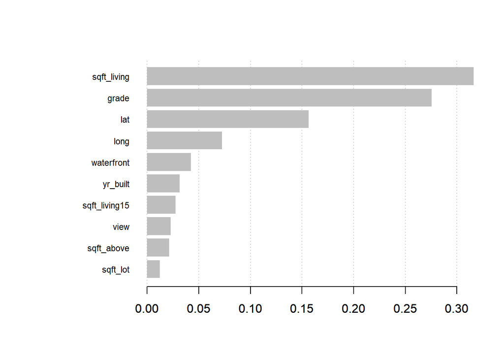

```r
xgb.plot.importance(importance_matrix, top_n = 10, measure = "Gain")
```

## Single Layer Neural Network With Cross Validation.

Now we will see if we can get even better results by using a single layer neural network. Since we have a variety of unit scales in our predictors we standardize the dataset before beginning. We use 10 fold cross validation to pick the optimal number of hidden nodes which was found to be 25. Best RMSE = $152,403.60

```r
maxs <- apply(homes_feat[,], 2, max)
mins <- apply(homes_feat[,], 2, min)

scaled.data <- as.data.frame(scale(homes_feat[,],center = mins, scale = maxs - mins))


scale.train = scaled.data[train, ]
scale.test = scaled.data[test, ]

set.seed(1)
fitControl <- trainControl(method = "cv",
                           number = 10) # 10-fold CV
nnetGrid <-  expand.grid(size = c(3,5,10,15,20,25), decay = 0)
homes.nn <- train(price~., data=scale.train, method='nnet',
                    trace = F,
                    trControl = fitControl,
                    tuneGrid = nnetGrid,
                    linout = TRUE)
homes.nn
```

```
## Neural Network
##
## 14048 samples
##    17 predictor
##
## No pre-processing
## Resampling: Cross-Validated (10 fold)
## Summary of sample sizes: 12643, 12644, 12644, 12643, 12643, 12642, ...
## Resampling results across tuning parameters:
##
##   size  RMSE        Rsquared   MAE
##    3    0.02423894  0.7933635  0.01521679
##    5    0.02063085  0.8145622  0.01259050
##   10    0.02002247  0.8261445  0.01225143
##   15    0.02298360  0.7391850  0.01424844
##   20    0.02001952  0.8272182  0.01209803
##   25    0.01993154  0.8290114  0.01207950
##
## Tuning parameter 'decay' was held constant at a value of 0
## RMSE was used to select the optimal model using the smallest value.
## The final values used for the model were size = 25 and decay = 0.
```

```r
#fitting the best model, size=25
set.seed(1)
fitControl <- trainControl(method = "none")
nnetGrid <-  expand.grid(size = 25, decay = 0)
homes.nn <- train(price~., data=scale.train, method='nnet',
                  trace = F,
                  trControl = fitControl,
                  tuneGrid = nnetGrid,
                  linout = TRUE)
yhat.nn15 = predict(homes.nn, scale.test)
mean((yhat.nn15-scale.test[,1])^2)
```

```
## [1] 0.0003994946
```

```r
#Unscale the data so we can make sense of the mse
price_full = homes_feat[,1]
yhat.nn15_unstandard = (yhat.nn15*((max(price_full) - min(price_full)))) + min(price_full)
adj.mse = mean((yhat.nn15_unstandard-homes_feat[test,1])^2)
adj.rmse = sqrt(mean((yhat.nn15_unstandard-homes_feat[test,1])^2))

adj.mse
```

```
## [1] 23226867024
```

```r
adj.rmse;
```

```
## [1] 152403.6
```